# TP Ciencia de Datos

Goldin Lucas

29/7/2020

# 1 Objetivos

Objetivos del trabajo:

1- Realizar un análisis de situación de la población mayor de 65 años de la ciudad de Buenos Aires (CABA) en comparación con la población nacional y su proyección para el 2040.

2- Visualizar como se distribuirá la población mayor de 65 años adentro del territorio de la CABA para el 2025.

# 2 Librerias

```r
library (knitr)
library(tidyverse)
library(readxl)
library(writexl)
library(janitor)
library(sf)
library(reshape)
library(kableExtra)
```

Se procederá a cargar la base de datos poblacional nacional del INDEC que proyecta la poblacional del año 2010 al 2040. Así también, se hará lo mismo con el data set del Gobierno de la Ciudad de Buenos Aires, que realiza el igual análisis de la población de la ciudad.

La no existencia de un .csv con todos los datos cargados de manera prolija, tanto para CABA como nación, requiere que se trabaje con los xls para poder realizar las tareas correspondientes posteriormente.

# 3 Carga Data Sets.

```r
#Base de datos
df_nac <- read_excel("C:/Users/lucas/Desktop/Ciencia de datos en salud/TpFinal/Nacional2040.xls",range = "A3:AF31")
df_caba <- read_excel("C:/Users/lucas/Desktop/Ciencia de datos en salud/TpFinal/CABA2040.xls")
```

# 4 Exploración Df Nacional.

Exploración del data frame nacional.

```r
unique(df_nac)
```

```
## # A tibble: 25 x 32
##    `Ambos sexos` ...2     ...3    ...4    ...5    ...6    ...7    ...8    ...9
##    <chr>         <chr>   <dbl>   <dbl>   <dbl>   <dbl>   <dbl>   <dbl>   <dbl>
##  1 Grupo de edad Año   NA      NA      NA      NA      NA      NA      NA
##  2 <NA>          <NA>  NA      NA      NA      NA      NA      NA      NA
##  3 <NA>          2010   2.01e3  2.01e3  2.01e3  2.01e3  2.02e3  2.02e3  2.02e3
##  4 Total         4078~  4.13e7  4.17e7  4.22e7  4.27e7  4.31e7  4.36e7  4.40e7
##  5 0-4           3571~  3.62e6  3.67e6  3.71e6  3.75e6  3.76e6  3.76e6  3.75e6
##  6 5-9           3507~  3.51e6  3.51e6  3.52e6  3.54e6  3.57e6  3.62e6  3.67e6
##  7 10-14         3541~  3.53e6  3.52e6  3.52e6  3.51e6  3.51e6  3.51e6  3.51e6
##  8 15-19         3559~  3.57e6  3.57e6  3.57e6  3.55e6  3.54e6  3.53e6  3.52e6
##  9 20-24         3346~  3.40e6  3.44e6  3.49e6  3.53e6  3.55e6  3.57e6  3.57e6
## 10 25-29         3166~  3.18e6  3.21e6  3.25e6  3.29e6  3.34e6  3.39e6  3.44e6
## # ... with 15 more rows, and 23 more variables: ...10 <dbl>, ...11 <dbl>,
## #   ...12 <dbl>, ...13 <dbl>, ...14 <dbl>, ...15 <dbl>, ...16 <dbl>,
## #   ...17 <dbl>, ...18 <dbl>, ...19 <dbl>, ...20 <dbl>, ...21 <dbl>,
## #   ...22 <dbl>, ...23 <dbl>, ...24 <dbl>, ...25 <dbl>, ...26 <dbl>,
## #   ...27 <dbl>, ...28 <dbl>, ...29 <dbl>, ...30 <dbl>, ...31 <dbl>,
## #   ...32 <dbl>
```

```r
#Dado que la row donde están los años, columna 1 fila 3, no tiene nombre, se le pondrá un nombre para que después cuando se transforme en el nombre de la variable no sea NA.
df_nac[3,1] <- "edad"
```

# 5 Limpieza y Transformación Df Nacional

Se harán las modificaciones pertinentes al data set nacional para obtener un nuevo, sin los valores totales, con tres variables de las cuales una sea población, otra grupo_edad y anio.

```r
#Usando el paquete Janitor, removemos las columna vacias con remove_empty y pasamos la fila 2 que posee los años como nombre de las variables con row_to_names. Por úlitmo transformas la varibale 2010 que es chr en num
df_nac1 <- clean_names(df_nac)%>%
  remove_empty(which = c("rows"),quiet = TRUE)%>%
  row_to_names( 2, remove_row = TRUE, remove_rows_above = TRUE)
df_nac1$`2010` = as.numeric(df_nac1$`2010`)

#Reexploramos el dataframe
str(df_nac1)
```

```
## tibble [22 x 32] (S3: tbl_df/tbl/data.frame)
##  $ edad: chr [1:22] "Total" "0-4" "5-9" "10-14" ...
##  $ 2010: num [1:22] 40788453 3571540 3507135 3541954 3559813 ...
##  $ 2011: num [1:22] 41261490 3622962 3507340 3530131 3573638 ...
##  $ 2012: num [1:22] 41733271 3671011 3511823 3521389 3574520 ...
##  $ 2013: num [1:22] 42202935 3712611 3522721 3515301 3566154 ...
##  $ 2014: num [1:22] 42669500 3745299 3541275 3510972 3553325 ...
##  $ 2015: num [1:22] 43131966 3764736 3570085 3508531 3539630 ...
##  $ 2016: num [1:22] 43590368 3757709 3621521 3508707 3527929 ...
##  $ 2017: num [1:22] 44044811 3748846 3669575 3513167 3519280 ...
##  $ 2018: num [1:22] 44494502 3738229 3711205 3524036 3513239 ...
##  $ 2019: num [1:22] 44938712 3726162 3743931 3542513 3508965 ...
##  $ 2020: num [1:22] 45376763 3712989 3763405 3571271 3506525 ...
##  $ 2021: num [1:22] 45808747 3698813 3756437 3622606 3506737 ...
##  $ 2022: num [1:22] 46234830 3683779 3747610 3670556 3511189 ...
```

[output cut: 18 more lines]

```r
#Usamos la función pivot_longer para readptar a las columnas necesarias nuestra

df_nac_tidy <- df_nac1  %>%
pivot_longer(cols = c(-'edad'), names_to = 'anio', values_to = 'poblacion',values_drop_na = TRUE)

#Remplazamos el valor "100 y más" por ">100" y "Total" por "total"
df_nac_tidy$edad[df_nac_tidy$edad == "100 y más"] <- ">100"
df_nac_tidy$edad[df_nac_tidy$edad == "Total"] <- "total"

#Exploramos para visualizar como quedo
head(df_nac_tidy)
```

```
## # A tibble: 6 x 3
##   edad  anio  poblacion
##   <chr> <chr>     <dbl>
## 1 total 2010   40788453
## 2 total 2011   41261490
## 3 total 2012   41733271
## 4 total 2013   42202935
## 5 total 2014   42669500
## 6 total 2015   43131966
```

```r
#Filtramos año 2010, para mostrar como quedo el data set.
df_nac_tidy_2010 <- df_nac_tidy%>%
  filter(anio == 2010)


kable(df_nac_tidy_2010,
      caption = "Distribución población año 2010",
       booktabs = TRUE, valign = 't') %>%
  kable_styling(bootstrap_options = "striped",
                full_width = F,
                position = "left")
```

Distribución población año 2010

| edad | anio | poblacion |
| --- | --- | --- |
| total | 2010 | 40788453 |
| 0-4 | 2010 | 3571540 |
| 5-9 | 2010 | 3507135 |
| 10-14 | 2010 | 3541954 |
| 15-19 | 2010 | 3559813 |
| 20-24 | 2010 | 3346483 |
| 25-29 | 2010 | 3166874 |
| 30-34 | 2010 | 3112375 |
| 35-39 | 2010 | 2711144 |
| 40-44 | 2010 | 2347809 |
| 45-49 | 2010 | 2212137 |
| 50-54 | 2010 | 2062422 |
| 55-59 | 2010 | 1877071 |
| 60-64 | 2010 | 1628569 |
| 65-69 | 2010 | 1304566 |
| 70-74 | 2010 | 1029030 |
| 75-79 | 2010 | 808031 |
| 80-84 | 2010 | 567436 |
| 85-89 | 2010 | 300955 |
| 90-94 | 2010 | 104982 |
| 95-99 | 2010 | 24631 |
| >100 | 2010 | 3496 |

```r
#Esto nos muestra, que el dataframe repite las observaciones de las primer variable por cada 6 años, en otras palabra va de 2010 a 2015, 2015,2021 y así sucesivamente hasta 2040.
```

# 6 Limpieza y Transformación Df caba

Transformado y limpiado el data frame nacional, pasamos a hacer lo mismo con el data frame caba(df_caba)

```r
#mediante el paquete janitor se limpiaran se removeran las columnas y filas vacias, y se limpiran los nombres de las variables
df_caba_tidy <- df_caba  %>%
    remove_empty(which = c("rows","cols"),quiet = TRUE)%>%
  clean_names()


#exploramos como quedo nuestro data set
head(df_caba_tidy)
```

```
## # A tibble: 6 x 19
##   proyecciones_de~ x2    x3    x4    x6    x7    x8    x10   x11   x12   x14
##   <chr>            <chr> <chr> <chr> <chr> <chr> <chr> <chr> <chr> <chr> <chr>
## 1 Edad             2010  <NA>  <NA>  2011  <NA>  <NA>  2012  <NA>  <NA>  2013
## 2 <NA>             Ambo~ Varo~ Muje~ Ambo~ Varo~ Muje~ Ambo~ Varo~ Muje~ Ambo~
## 3 Total            3028~ 1405~ 1622~ 3033~ 1409~ 1623~ 3038~ 1414~ 1624~ 3044~
## 4 0-4              2131~ 1096~ 1034~ 2118~ 1090~ 1028~ 2108~ 1085~ 1022~ 2102~
## 5 5-9              2010~ 1027~ 98354 2042~ 1044~ 99774 2070~ 1060~ 1009~ 2079~
## 6 10-14            1904~ 95994 94500 1886~ 95303 93350 1876~ 95051 92628 1887~
## # ... with 8 more variables: x15 <chr>, x16 <chr>, x18 <chr>, x19 <chr>,
## #   x20 <chr>, x22 <chr>, x23 <chr>, x24 <chr>
```

```r
#Renombramos la primer columna por proyeccciones.
df_caba_tidy <- df_caba_tidy %>%
  rename(c( proyecciones_de_poblacion_por_sexo_y_grupos_quinquenales_de_edad_ciudad_autonoma_de_buenos_aires_anos_2010_2040= "proyecciones"  ))

#Para comprender la dificultad que requería la transformación de este data set a la hora de su limpieza, se motrara un kable con una parte del data set.
```

| proyecciones | x2 | x3 | x4 | x6 | x7 | x8 | x10 | x11 | x12 | x14 | x15 | x16 | x18 | x19 | x20 | x22 | x23 | x24 |
| --- | --- | --- | --- | --- | --- | --- | --- | --- | --- | --- | --- | --- | --- | --- | --- | --- | --- | --- |
| Edad | 2010 | NA | NA | 2011 | NA | NA | 2012 | NA | NA | 2013 | NA | NA | 2014 | NA | NA | 2015 | NA | NA |
| NA | Ambos sexos | Varones | Mujeres | Ambos sexos | Varones | Mujeres | Ambos sexos | Varones | Mujeres | Ambos sexos | Varones | Mujeres | Ambos sexos | Varones | Mujeres | Ambos sexos | Varones | Mujeres |
| Total | 3028481 | 1405566 | 1622915 | 3033639 | 1409835 | 1623804 | 3038860 | 1414105 | 1624755 | 3044076 | 1418339 | 1625737 | 3049229 | 1422507 | 1626722 | 3054267 | 1426582 | 1627685 |
| 0-4 | 213114 | 109643 | 103471 | 211877 | 109070 | 102807 | 210881 | 108595 | 102286 | 210242 | 108275 | 101967 | 209952 | 108105 | 101847 | 209883 | 108023 | 101860 |
| 5-9 | 201055 | 102701 | 98354 | 204270 | 104496 | 99774 | 207018 | 106030 | 100988 | 207913 | 106597 | 101316 | 207229 | 106372 | 100857 | 205617 | 105680 | 99937 |
| 90-94 | 17067 | 3976 | 13091 | 18528 | 4526 | 14002 | 19738 | 4961 | 14777 | 20748 | 5308 | 15440 | 21619 | 5594 | 16025 | 22407 | 5843 | 16564 |
| 95-99 | 4438 | 772 | 3666 | 4349 | 724 | 3625 | 4539 | 787 | 3752 | 4916 | 916 | 4000 | 5373 | 1084 | 4289 | 5920 | 1270 | 4650 |
| 100 y > | 650 | 104 | 546 | 776 | 138 | 638 | 865 | 156 | 709 | 941 | 170 | 771 | 1045 | 179 | 866 | 1111 | 182 | 929 |
| NA | NA | NA | NA | NA | NA | NA | NA | NA | NA | NA | NA | NA | NA | NA | NA | NA | NA | (continúa) |
| Edad | 2016 | NA | NA | 2017 | NA | NA | 2018 | NA | NA | 2019 | NA | NA | 2020 | NA | NA | 2021 | NA | NA |
| NA | Ambos sexos | Varones | Mujeres | Ambos sexos | Varones | Mujeres | Ambos sexos | Varones | Mujeres | Ambos sexos | Varones | Mujeres | Ambos sexos | Varones | Mujeres | Ambos sexos | Varones | Mujeres |
| Total | 3059122 | 1430531 | 1628591 | 3063728 | 1434323 | 1629405 | 3068043 | 1437936 | 1630107 | 3072029 | 1441350 | 1630679 | 3075646 | 1444545 | 1631101 | 3078836 | 1447495 | 1631341 |
| 0-4 | 209174 | 107662 | 101512 | 208194 | 107161 | 101033 | 206987 | 106543 | 100444 | 205585 | 105824 | 99761 | 204007 | 105015 | 98992 | 202276 | 104126 | 98150 |
| 5-9 | 204345 | 105089 | 99256 | 203314 | 104598 | 98716 | 202637 | 104260 | 98377 | 202308 | 104073 | 98235 | 202200 | 103973 | 98227 | 201450 | 103592 | 97858 |

Se separan los df por lustros y se limpian, se seleccionan filas a utilizar

```r
df_caba_2010_2015 <- df_caba_tidy[1:24,]%>%
  remove_empty(which = c("rows","cols"),quiet = TRUE)%>%
  clean_names()%>%
  row_to_names( 1, remove_row = TRUE, remove_rows_above = TRUE)%>%
  select("Edad","2010","2011","2012","2013","2014","2015")%>%
  filter (Edad !=0 )%>%
  pivot_longer(cols = c(-'Edad'), names_to = 'anio', values_to = 'poblacion',values_drop_na = TRUE)%>%
  clean_names()
head(df_caba_2010_2015)
```

```
## # A tibble: 6 x 3
##   edad  anio  poblacion
##   <chr> <chr> <chr>
## 1 Total 2010  3028481
## 2 Total 2011  3033639
## 3 Total 2012  3038860
## 4 Total 2013  3044076
## 5 Total 2014  3049229
## 6 Total 2015  3054267
```

## 6.1 df caba 2016 2021

```r
df_caba_2016_2021 <- df_caba_tidy[26:49,]%>%
 remove_empty(which = c("rows","cols"),quiet = TRUE)%>%
  clean_names()%>%
  row_to_names( 1, remove_row = TRUE, remove_rows_above = TRUE)%>%
  rename(c(Edad = "edad"))%>%
  select("edad","2016","2017","2018","2019","2020","2021")%>%
  filter (edad !=0 )%>%
  pivot_longer(cols = c(-'edad'), names_to = 'anio', values_to = 'poblacion',values_drop_na = TRUE)
```

## 6.2 df caba 2022-2027

```r
#df_caba_2022_2027
df_caba_2022_2027 <- df_caba_tidy[51:74,]%>%
  remove_empty(which = c("rows","cols"),quiet = TRUE)%>%
  clean_names()%>%
  row_to_names( 1, remove_row = TRUE, remove_rows_above = TRUE)%>%
  rename(c(Edad = "edad"))%>%
  select("edad","2022","2023","2024","2025","2026","2027")%>%
  filter (edad !=0 )%>%
  pivot_longer(cols = c(-'edad'), names_to = 'anio', values_to = 'poblacion',values_drop_na = TRUE)
```

## 6.3 df caba 2028-2033

```r
df_caba_2028_2033 <- df_caba_tidy[76:99,]%>%
  remove_empty(which = c("rows","cols"),quiet = TRUE)%>%
  clean_names()%>%
  row_to_names( 1, remove_row = TRUE, remove_rows_above = TRUE)%>%
  rename(c(Edad = "edad"))%>%
  select("edad","2028","2029","2030","2031","2032","2033")%>%
  filter (edad !=0 )%>%
  pivot_longer(cols = c(-'edad'), names_to = 'anio', values_to = 'poblacion',values_drop_na = TRUE)
```

## 6.4 df caba 2034-2039

```r
df_caba_2034_2039 <- df_caba_tidy[101:124,]%>%
    remove_empty(which = c("rows","cols"),quiet = TRUE)%>%
  clean_names()%>%
  row_to_names( 1, remove_row = TRUE, remove_rows_above = TRUE)%>%
  rename(c(Edad = "edad"))%>%
  select("edad","2034","2035","2036","2037","2038","2039")%>%
  filter (edad !=0 )%>%
  pivot_longer(cols = c(-'edad'), names_to = 'anio', values_to = 'poblacion',values_drop_na = TRUE)
```

## 6.5 df caba 2040

```r
df_caba_2040<- df_caba_tidy[126:149,]%>%
    remove_empty(which = c("rows","cols"),quiet = TRUE)%>%
  clean_names()%>%
  row_to_names( 1, remove_row = TRUE, remove_rows_above = TRUE)%>%
  rename(c(Edad = "edad"))%>%
  select("edad","2040")%>%
  filter (edad !=0 )%>%
  pivot_longer(cols = c(-'edad'), names_to = 'anio', values_to = 'poblacion',values_drop_na = TRUE)
```

## 6.6 Union de df

```r
#Unir para tener un solo df.

df_caba_unido <-df_caba_2010_2015 %>%
  add_row(df_caba_2016_2021)%>%
  add_row(df_caba_2022_2027)%>%
  add_row(df_caba_2028_2033)%>%
  add_row(df_caba_2034_2039)%>%
  add_row(df_caba_2040)

#Si visualizamos nuevamente el kable, se podrá observar la presencia en las observaciones del valor "100 y más" y "100 y >", por los que se los remplazará por ">100", al mismo tiempo se realizará lo mismo con "Total" modificandolo "total"

df_caba_unido$edad[df_caba_unido$edad == "100 y más"] <- ">100"
df_caba_unido$edad[df_caba_unido$edad == "100 y >"] <- ">100"
df_caba_unido$edad[df_caba_unido$edad == "Total"] <- "total"

#Se explora para asegurar que las variable población sea un int
str(df_caba_unido)
```

```
## tibble [682 x 3] (S3: tbl_df/tbl/data.frame)
##  $ edad     : chr [1:682] "total" "total" "total" "total" ...
##  $ anio     : chr [1:682] "2010" "2011" "2012" "2013" ...
##  $ poblacion: chr [1:682] "3028481" "3033639" "3038860" "3044076" ...
```

```r
#Se pasa población a int
df_caba_unido$poblacion <- as.numeric(df_caba_unido$poblacion)
```

# 7 Etiquetado

## 7.1 Adición de etiquetas df nacional

Según el grupo etario al cual pertenezca se procederá a realizar una clasificacón por categoría, etiquetandolos en mayores de 65, población economicamente activa(PEA) y menores de 14.

```r
 df_nac_grupos_separado <-  df_nac_tidy %>%
  mutate(grupo =case_when(edad == "0-4"|edad == "5-9"|edad == "10-14" ~ "menores_14",
                          edad == '15-19'| edad == '20-24'| edad == '25-29'|edad == '30-34'|edad == '35-39'|edad == '40-44'|edad == '45-49'|edad == '50-54'|edad == '55-59'|edad ==  '60-64'~ "pea_15_64",
                          edad == '65-69'|edad =='70-74'|edad =='75-79'|edad ==  '80-84'|edad =='85-89'|edad =='90-94'|edad =='95-99'|edad ==  '>100' ~ "mayores_65",
                          edad == "total" ~ "total"))
  df_nac_grupos <- df_nac_grupos_separado%>%
  group_by(grupo,anio)%>%
  summarise(poblacion = sum(poblacion))%>%
  ungroup()
  head(df_nac_grupos)
```

```
## # A tibble: 6 x 3
##   grupo      anio  poblacion
##   <chr>      <chr>     <dbl>
## 1 mayores_65 2010    4143127
## 2 mayores_65 2011    4228548
## 3 mayores_65 2012    4321424
## 4 mayores_65 2013    4420825
## 5 mayores_65 2014    4525553
## 6 mayores_65 2015    4634654
```

## 7.2 Adición de etiquetas df caba

Al igual que lo hecho anteriormente, se hará lo mismo el del df caba.

```r
 df_caba_grupos_separado <-  df_caba_unido %>%
  mutate(grupo =case_when(edad == "0-4"|edad == "5-9"|edad == "10-14" ~ "menores_14",
                          edad == '15-19'| edad == '20-24'| edad == '25-29'|edad == '30-34'|edad == '35-39'|edad == '40-44'|edad == '45-49'|edad == '50-54'|edad == '55-59'|edad ==  '60-64'~ "pea_15_64",
                          edad == '65-69'|edad =='70-74'|edad =='75-79'|edad ==  '80-84'|edad =='85-89'|edad =='90-94'|edad =='95-99'|edad ==  '>100' ~ "mayores_65",
                          edad == "total" ~ "total"))

#Dada la posibilidad de poder realizar otros gráficos a futuro es que no se realizan todas las operaciones dentro del mismo data set.
  df_caba_grupos <- df_caba_grupos_separado%>%
  group_by(grupo,anio)%>%
  summarise(poblacion = sum(poblacion))%>%
  ungroup()
```

# 8 Población

Antes de realizar cualquier análisis respecto a la situación de los AM, conoceremos la población total por quintiles que tendrá el territorio nacional y la CABA. Se realizará una tabla que permita mostrar estos datos.

```r
df_caba_total <- df_caba_unido %>%
  filter(edad == "total" & (anio == 2010|anio == 2015|anio == 2020|anio == 2025|anio == 2030|anio == 2035|anio== 2040)) %>%
  select(anio,poblacion)
df_nac_total <- df_nac_tidy %>%
  filter(edad== "total" & (anio == 2010|anio == 2015|anio == 2020|anio == 2025|anio == 2030|anio == 2035|anio== 2040)) %>%
  select(anio,poblacion)
```

Población Nacional por lustro

| Año | Población |
| --- | --- |
| 2010 | 40788453 |
| 2015 | 43131966 |
| 2020 | 45376763 |
| 2025 | 47473760 |
| 2030 | 49407265 |
| 2035 | 51177087 |
| 2040 | 52778477 |

Población CABA por lustro

| Año | Población |
| --- | --- |
| 2010 | 3028481 |
| 2015 | 3054267 |
| 2020 | 3075646 |
| 2025 | 3086680 |
| 2030 | 3084450 |
| 2035 | 3069488 |
| 2040 | 3043704 |

A pesar de los múltiples análisis que se podrían hacer al respecto, el dato el cual resultará de vital importancia para entender los resultados futuros será que a pesar del crecimiento poblaciones que experimentará la Argentina, la CABA mantendrá su población estable.

# 9 Índices

La forma más gráfica de poder conocer la situación de los mayores de 65 años de forma comparativa en CABA y nación y sus proyecciones, es mediante dos índices: El primero es porcentaje de mayores de 65 años sobre los totales poblacionales estimados comprando la CABA con nación en el año 2010 y 2040 El segundo es el índice de envejecimiento como medida comparativa de la situación de los menores de 14 años por sobre la de los mayores de 65 a lo largo de los años analizados Este índice tiene como ventaja la posibilidad de visualizar como evolucionaran los mayores de 65 años a lo largo del tiempo en relación con los menores de 14 como medida de desarrollo demográfico, aunque tiene algunas limitantes como la exclusión de lo sucedido con la PEA y la evolución de los menores de 14 años a lo largo del tiempo.

## 9.1 Porcentaje de mayores de 65 años por lustro, caba vs nación

Se analizarán en los años 2010, 2015, 2020, 2025, 2030, 2035 y 2040 el porcentaje de adultos mayores sobre el total poblacional proyectado para caba y nación

### 9.1.1 Porcentaje de mayores 65 nación y caba

```r
total_nac <- df_nac_grupos_separado%>%
  filter(grupo == "total" & (anio == 2010|anio == 2015|anio == 2020|anio == 2025|anio == 2030|anio == 2035|anio== 2040))

df_nac_mayores_65 <- df_nac_grupos
  df_nac_mayores_65 <- df_nac_mayores_65 %>%
  filter(grupo== "mayores_65" & (anio == 2010|anio == 2015|anio == 2020|anio == 2025|anio == 2030|anio == 2035|anio== 2040))
  porcentaje = (df_nac_mayores_65$poblacion/total_nac$poblacion*100)
  df_nac_mayores_65 <- df_nac_mayores_65 %>%
  mutate(porcentaje) %>%
  mutate(jurisdiccion = "nacion")


head(df_nac_mayores_65)
```

```
## # A tibble: 6 x 5
##   grupo      anio  poblacion porcentaje jurisdiccion
##   <chr>      <chr>     <dbl>      <dbl> <chr>
## 1 mayores_65 2010    4143127       10.2 nacion
## 2 mayores_65 2015    4634654       10.7 nacion
## 3 mayores_65 2020    5227722       11.5 nacion
## 4 mayores_65 2025    5868496       12.4 nacion
## 5 mayores_65 2030    6525778       13.2 nacion
## 6 mayores_65 2035    7185947       14.0 nacion
```

### 9.1.2 Porcentaje de mayores 65 años CABA

```r
total_caba <- df_caba_grupos_separado%>%
  filter(grupo == "total" & (anio == 2010|anio == 2015|anio == 2020|anio == 2025|anio == 2030|anio == 2035|anio== 2040))
df_caba_mayores_65 <- df_caba_grupos %>%
  filter(grupo== "mayores_65" & (anio == 2010|anio == 2015|anio == 2020|anio == 2025|anio == 2030|anio == 2035|anio== 2040))
porcentaje = df_caba_mayores_65$poblacion/total_caba$poblacion*100
df_caba_mayores_65 <- df_caba_mayores_65%>%
  mutate(porcentaje) %>%
  mutate(jurisdiccion = "caba")

head(df_caba_mayores_65)
```

```
## # A tibble: 6 x 5
##   grupo      anio  poblacion porcentaje jurisdiccion
##   <chr>      <chr>     <dbl>      <dbl> <chr>
## 1 mayores_65 2010     470815       15.5 caba
## 2 mayores_65 2015     485397       15.9 caba
## 3 mayores_65 2020     505435       16.4 caba
## 4 mayores_65 2025     530274       17.2 caba
## 5 mayores_65 2030     550241       17.8 caba
## 6 mayores_65 2035     572910       18.7 caba
```

### 9.1.3 Gráfico

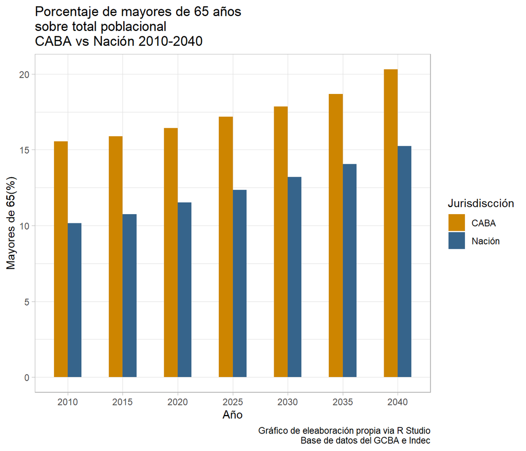

```r
mayores_caba_nacion <- df_caba_mayores_65
mayores_caba_nacion <- add_row(mayores_caba_nacion, df_nac_mayores_65)

gr_65 <- ggplot(mayores_caba_nacion, aes(x=anio, y = porcentaje, fill = jurisdiccion)) +
  geom_bar(stat="identity", width=0.5, position="dodge") +
  scale_fill_manual(values=c("orange3", "steelblue4"),labels = c("CABA", "Nación")) +
  labs (x = "Año",
           y= "Mayores de 65(%)",
           fill = "Jurisdiscción",
           caption = "Gráfico de eleaboración propia via R Studio\nBase de datos del GCBA e Indec") +
  ggtitle("Porcentaje de mayores de 65 años\nsobre total poblacional\nCABA vs Nación 2010-2040") + theme_light()
gr_65
```

## 9.2 Índice de envejecimiento

### 9.2.1 Cálculo indice de envejecimiento Nación

```r
df_nac_porcentaje_total <- df_nac_grupos %>%
  filter(grupo=="mayores_65")
df_nac_porcentaje_ie <- df_nac_grupos %>%
  filter(grupo=="menores_14") %>%
  left_join(df_nac_porcentaje_total,
                          by = "anio")
df_nac_porcentaje_ie <- mutate(df_nac_porcentaje_ie, indice = (df_nac_porcentaje_ie$poblacion.y/df_nac_porcentaje_ie$poblacion.x)*100)
head(df_nac_porcentaje_ie)
```

```
## # A tibble: 6 x 6
##   grupo.x    anio  poblacion.x grupo.y    poblacion.y indice
##   <chr>      <chr>       <dbl> <chr>            <dbl>  <dbl>
## 1 menores_14 2010     10620629 mayores_65     4143127   39.0
## 2 menores_14 2011     10660433 mayores_65     4228548   39.7
## 3 menores_14 2012     10704223 mayores_65     4321424   40.4
## 4 menores_14 2013     10750633 mayores_65     4420825   41.1
## 5 menores_14 2014     10797546 mayores_65     4525553   41.9
## 6 menores_14 2015     10843352 mayores_65     4634654   42.7
```

### 9.2.2 Cálculo indice de envejecimiento CABA

```r
df_caba_porcentaje_total <- df_caba_grupos %>%
  filter(grupo=="mayores_65")
df_caba_porcentaje_ie <- df_caba_grupos %>%
  filter(grupo=="menores_14") %>%
  left_join(df_caba_porcentaje_total,
                          by = "anio")
df_caba_porcentaje_ie <- mutate(df_caba_porcentaje_ie, indice = (df_caba_porcentaje_ie$poblacion.y/df_caba_porcentaje_ie$poblacion.x)*100)
head(df_caba_porcentaje_ie)
```

```
## # A tibble: 6 x 6
##   grupo.x    anio  poblacion.x grupo.y    poblacion.y indice
##   <chr>      <chr>       <dbl> <chr>            <dbl>  <dbl>
## 1 menores_14 2010       604663 mayores_65      470815   77.9
## 2 menores_14 2011       604800 mayores_65      473016   78.2
## 3 menores_14 2012       605578 mayores_65      475650   78.5
## 4 menores_14 2013       606928 mayores_65      478645   78.9
## 5 menores_14 2014       608583 mayores_65      481914   79.2
## 6 menores_14 2015       610095 mayores_65      485397   79.6
```

### 9.2.3 Gráfico del indice de Envejecimiento CABA VS Nación

```r
#Para gráficar se requiere que este todo dentro de un data set, por lo que se le agregrá la variables juridiscción a fin de luego poder gráficar según está.
ie_total <- df_caba_porcentaje_ie%>%
  select(anio, indice)%>%
  mutate (jurisdiccion = "caba")
ie_total_nac <- df_nac_porcentaje_ie%>%
  select(anio, indice)%>%
  mutate (jurisdiccion = "nacion")
ie_total <- ie_total%>%
  add_row(ie_total_nac)



gr_ie <- ggplot(ie_total, aes((x=as.numeric(anio)),y=indice, color = jurisdiccion)) +
  geom_line(stat="identity", size= 1.25 , alpha =4) + geom_point(size=2)+

  labs( title = "I.Envejecimiento\nCABA vs Nación\n2010-2040",
        x = "Año",
        y = "Indice de Envejecimiento(%)",
        color = "Jurisdicción",
        caption = "Gráfico de eleaboración propia via R Studio\nBase de datos del GCBA e Indec") + scale_color_manual(values=c("orange3", "steelblue4"), labels = c("CABA", "Nación")) + theme_light()
```

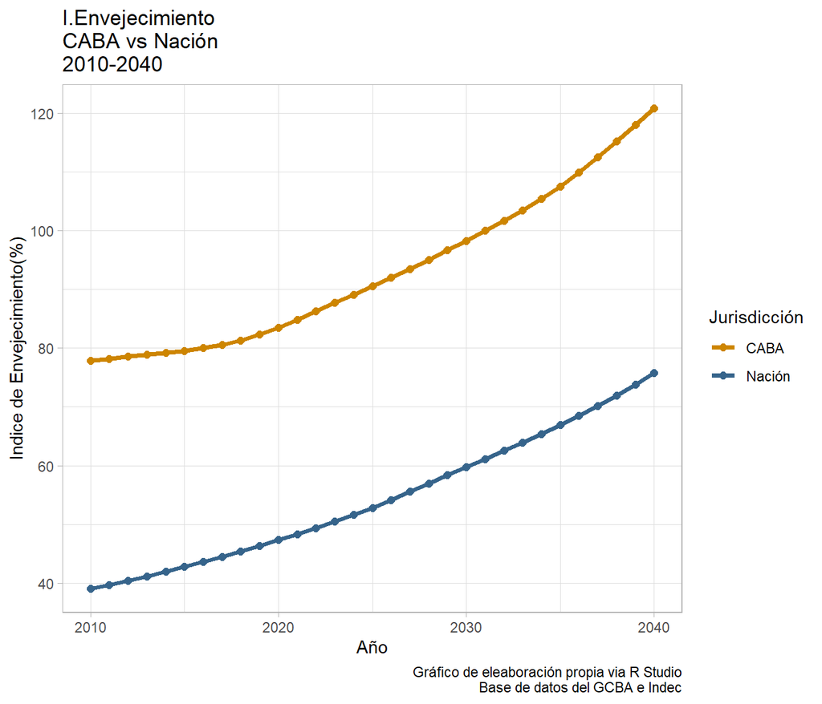

```r
gr_ie
```

# 10 Data Set comunas

El siguiente data set del Gobierno de la Ciudad De Buenos Aires, desarrolla las proyecciones por grupo etario para el año 2025 por comuna.

```r
dfcomunas<- read_excel("C:/Users/lucas/Desktop/Ciencia de datos en salud/Tp/viejas db/PBP_CO1025.xls", sheet = '2025' , range = "A3:Q21")
head(dfcomunas)
```

```
## # A tibble: 6 x 17
##   grupos  total    `1`    `2`    `3`    `4`    `5`    `6`    `7`    `8`    `9`
##   <chr>   <dbl>  <dbl>  <dbl>  <dbl>  <dbl>  <dbl>  <dbl>  <dbl>  <dbl>  <dbl>
## 1 Total  3.09e6 259205 149389 193884 241193 188053 186028 242921 230745 171921
## 2 0-4    1.94e5  16209   6556  11236  18611  10346  10466  17126  22230  11542
## 3 5-9    1.96e5  15081   6425  11223  19236  10651  10358  17394  22090  12487
## 4 10-14  1.95e5  15237   6400  11303  19968  10551   9724  17419  21930  12653
## 5 15-19  1.96e5  16094   8664  11600  18908  10796   9861  16750  20506  11956
## 6 20-24  1.97e5  19994  13201  13835  16031  11271   9883  15446  17062   9862
## # ... with 6 more variables: `10` <dbl>, `11` <dbl>, `12` <dbl>, `13` <dbl>,
## #   `14` <dbl>, `15` <dbl>
```

En datos públicos del Gobierno de la Ciudad de Buenos Aires, solo se encuentran las proyecciones poblacionales por comunas correspondientes al periodo 2010-2025. Sin poder hallarse análisis respecto a que es lo que sucederá por comunas para el 2040.

## 10.1 Transofrmación del data set

```r
head(dfcomunas)
```

```
## # A tibble: 6 x 17
##   grupos  total    `1`    `2`    `3`    `4`    `5`    `6`    `7`    `8`    `9`
##   <chr>   <dbl>  <dbl>  <dbl>  <dbl>  <dbl>  <dbl>  <dbl>  <dbl>  <dbl>  <dbl>
## 1 Total  3.09e6 259205 149389 193884 241193 188053 186028 242921 230745 171921
## 2 0-4    1.94e5  16209   6556  11236  18611  10346  10466  17126  22230  11542
## 3 5-9    1.96e5  15081   6425  11223  19236  10651  10358  17394  22090  12487
## 4 10-14  1.95e5  15237   6400  11303  19968  10551   9724  17419  21930  12653
## 5 15-19  1.96e5  16094   8664  11600  18908  10796   9861  16750  20506  11956
## 6 20-24  1.97e5  19994  13201  13835  16031  11271   9883  15446  17062   9862
## # ... with 6 more variables: `10` <dbl>, `11` <dbl>, `12` <dbl>, `13` <dbl>,
## #   `14` <dbl>, `15` <dbl>
```

```r
str(dfcomunas)
```

```
## tibble [18 x 17] (S3: tbl_df/tbl/data.frame)
##  $ grupos: chr [1:18] "Total" "0-4" "5-9" "10-14" ...
##  $ total : num [1:18] 3086680 194379 196125 195294 196262 ...
##  $ 1     : num [1:18] 259205 16209 15081 15237 16094 ...
##  $ 2     : num [1:18] 149389 6556 6425 6400 8664 ...
##  $ 3     : num [1:18] 193884 11236 11223 11303 11600 ...
##  $ 4     : num [1:18] 241193 18611 19236 19968 18908 ...
##  $ 5     : num [1:18] 188053 10346 10651 10551 10796 ...
##  $ 6     : num [1:18] 186028 10466 10358 9724 9861 ...
##  $ 7     : num [1:18] 242921 17126 17394 17419 16750 ...
##  $ 8     : num [1:18] 230745 22230 22090 21930 20506 ...
##  $ 9     : num [1:18] 171921 11542 12487 12653 11956 ...
##  $ 10    : num [1:18] 170896 10261 11177 11044 10907 ...
##  $ 11    : num [1:18] 190225 10697 12060 12018 11607 ...
##  $ 12    : num [1:18] 215505 13222 13098 12584 12394 ...
##  $ 13    : num [1:18] 236781 13403 12709 12356 12596 ...
##  $ 14    : num [1:18] 227360 11812 10975 10857 12457 ...
##  $ 15    : num [1:18] 182574 10662 11161 11250 11166 ...
```

## 10.2 calculo % mayores de 65 por comunas en el año 2025

```r
mayores <- c('65-69','70-74','75-79', '80 y más')
dfcomunas2025 <- dfcomunas %>%
  filter(grupos %in% mayores | grupos == "Total")%>%
  pivot_longer(cols = c(-'grupos'), names_to = 'comuna', values_to = "poblacion")%>%
  filter(comuna != "total")
dfcomunas_mayores <- dfcomunas2025%>%
  filter(grupos != "Total")%>%
  group_by(comuna)%>%
  summarise(mayor65=sum(poblacion))%>%
  ungroup()
dfcomunas_total<- dfcomunas2025%>%
  filter(grupos == "Total")
dfcomunas_mayores <- dfcomunas_mayores %>%
  left_join(dfcomunas_total, poblacion, by = "comuna")
dfcomunas_mayores <- mutate(dfcomunas_mayores, porcetaje = (mayor65/poblacion*100))


dfcomunas_mayores$comuna <-as.numeric(dfcomunas_mayores$comuna)
dfcomunas_mayores <- arrange(dfcomunas_mayores, comuna)
```

## 10.3 modificacion data frame comunas mayores

QUe el string comunas, tenga una C adelante de la comuna para poder identificarla posteriormente en el gráfico

```r
str(dfcomunas_mayores)
```

```
## tibble [15 x 5] (S3: tbl_df/tbl/data.frame)
##  $ comuna   : num [1:15] 1 2 3 4 5 6 7 8 9 10 ...
##  $ mayor65  : num [1:15] 38924 31845 32910 32654 34282 ...
##  $ grupos   : chr [1:15] "Total" "Total" "Total" "Total" ...
##  $ poblacion: num [1:15] 259205 149389 193884 241193 188053 ...
##  $ porcetaje: num [1:15] 15 21.3 17 13.5 18.2 ...
```

```r
nombre <- paste0("C",dfcomunas_mayores$comuna, collapse = " ")
nombre <- as.data.frame(strsplit(nombre," "), col.names= "comunas_string")
dfcomunas_mayores <- dfcomunas_mayores%>%
  add_column(nombre)
```

## 10.4 Carga de mapa de comunas

```r
mapa_comunas <- st_read('http://cdn.buenosaires.gob.ar/datosabiertos/datasets/comunas/CABA_comunas.geojson')
#Ordenos mapa de comunas por número de comuna.
arrange(mapa_comunas, COMUNAS)
```

```
## Simple feature collection with 15 features and 6 fields
## geometry type:  MULTIPOLYGON
## dimension:      XY
## bbox:           xmin: -58.53152 ymin: -34.70529 xmax: -58.33515 ymax: -34.52649
## geographic CRS: WGS 84
## First 10 features:
##                                                                            BARRIOS
## 1     CONSTITUCION - MONSERRAT - PUERTO MADERO -  RETIRO - SAN NICOLAS - SAN TELMO
## 2                                                                         RECOLETA
## 3                                                        BALVANERA - SAN CRISTOBAL
## 4                               BARRACAS - BOCA - NUEVA POMPEYA - PARQUE PATRICIOS
## 5                                                                  ALMAGRO - BOEDO
## 6                                                                        CABALLITO
## 7                                                        FLORES - PARQUE CHACABUCO
## 8                                   VILLA LUGANO - VILLA RIACHUELO - VILLA SOLDATI
## 9                                          LINIERS - MATADEROS - PARQUE AVELLANEDA
## 10 FLORESTA - MONTE CASTRO - VELEZ SARSFIELD - VERSALLES - VILLA LURO - VILLA REAL
##    PERIMETRO     AREA COMUNAS ID         OBJETO                       geometry
## 1   36102.20 17794569       1 14 LIMITE COMUNAL MULTIPOLYGON (((-58.36854 -...
## 2   21452.84  6317265       2  1 LIMITE COMUNAL MULTIPOLYGON (((-58.38 -34....
## 3   10486.26  6385991       3 10 LIMITE COMUNAL MULTIPOLYGON (((-58.41192 -...
## 4   35423.28 21684645       4 13 LIMITE COMUNAL MULTIPOLYGON (((-58.39908 -...
## 5   12323.43  6660603       5  2 LIMITE COMUNAL MULTIPOLYGON (((-58.41287 -...
## 6   10990.96  6851029       6  3 LIMITE COMUNAL MULTIPOLYGON (((-58.43061 -...
## 7   17972.26 12422901       7  4 LIMITE COMUNAL MULTIPOLYGON (((-58.452 -34...
## 8   20935.01 22216902       8 12 LIMITE COMUNAL MULTIPOLYGON (((-58.44913 -...
## 9   21411.74 16505306       9  5 LIMITE COMUNAL MULTIPOLYGON (((-58.51925 -...
## 10  18332.04 12656557      10  6 LIMITE COMUNAL MULTIPOLYGON (((-58.48834 -...
```

## 10.5 Dibujo del mapa cargado

```r
names(mapa_comunas)
```

```
## [1] "BARRIOS"   "PERIMETRO" "AREA"      "COMUNAS"   "ID"        "OBJETO"
## [7] "geometry"
```

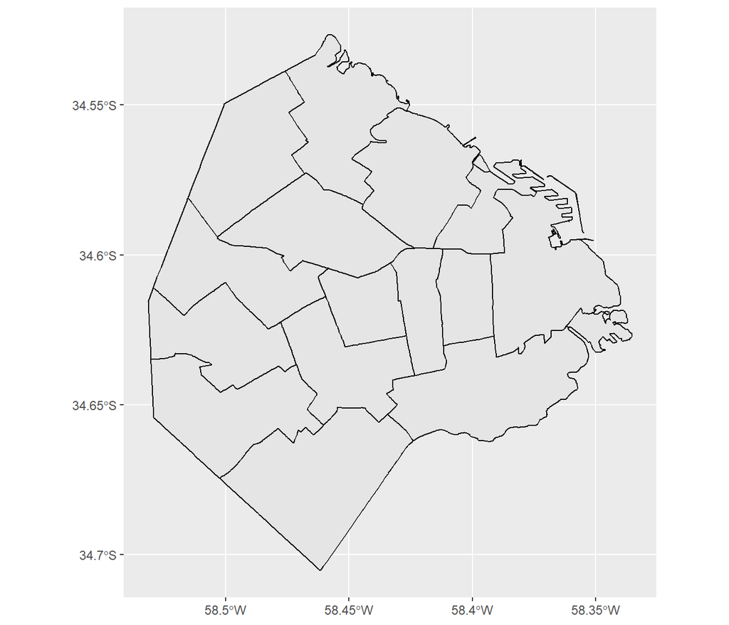

```r
mapa_comunas_tidy <- mapa_comunas%>%
  clean_names()%>%
 arrange(comunas)%>%
  select(comunas,geometry)
mapa_comunas_ggplot <- ggplot() +
  geom_sf(data=mapa_comunas_tidy, colour = "black")
mapa_comunas_ggplot
```

## 10.6 Centroide

Se requiere del centroide dado que es el punto de referencia que se utilizará para ponerle el nombre a cada comuna

```r
comunas_centroide <- st_point_on_surface(mapa_comunas_tidy)
mapa_comunas_centroide <- mapa_comunas_ggplot +
  geom_sf(data=comunas_centroide, size=0.5)
```

## 10.7 De centroides a puntos

```r
#Se pasa los centroides geometricos a puntos y se crea un data frame con las variables x e y
comunas_x_y <- as.data.frame(sf::st_coordinates(comunas_centroide))
#Se agrega la columna comuna y porcetaje al df que se dibujara
comunas_x_y <- comunas_x_y%>%
  add_column(comuna = dfcomunas_mayores$comunas_string)%>%
  add_column(porcentaje = dfcomunas_mayores$porcetaje)

#El data set comunas tiene la geometria de las comunas, se le agrega porcentaje para que tenga de donde poder hacer el fill a la hora del gráficar.

mapa_comunas_tidy <- mapa_comunas_tidy%>%
  add_column(porcentaje = dfcomunas_mayores$porcetaje)



#Modifico el punto de las comuna 11, para que no se tape con el vértice del mapa.
comunas_x_y$porcentaje <- format(comunas_x_y$porcentaje, digits = 2,nsmall=1)
comunas_x_y[11,1]=-58.48899
```

## 10.8 Gráfico comunas

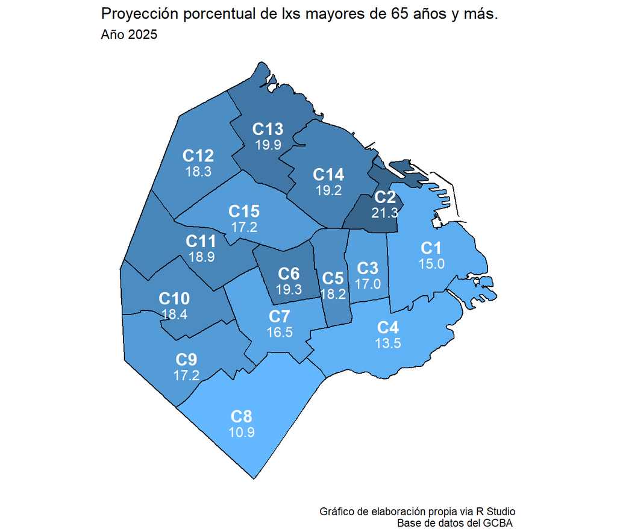

```r
mapa_comunas_mayores <- ggplot() +
  geom_sf(data=mapa_comunas_tidy,
          aes(fill = porcentaje),
          colour = "black",
          stat = "sf",
          position = "identity",
          na.rm = FALSE,
          inherit.aes = FALSE,
          show.legend = FALSE) +


  geom_text(data = comunas_x_y,
            aes(X, Y, label = comuna),
            colour = "white",
            size = 5,
            fontface  = "bold")+
  geom_text(data = comunas_x_y,
            aes(X, Y, label = porcentaje
                ),
            colour = "white",
            size = 4,
            vjust=2) +
  labs(title = "Proyección porcentual de lxs mayores de 65 años y más.",
       subtitle = "Año 2025",
        fill = "Porcentaje",
       caption = "Gráfico de elaboración propia via R Studio\n Base de datos del GCBA ") +
  theme(axis.title.x=element_blank(),
        axis.title.y=element_blank()) +
    theme_void()

#Pinto a las comunas según el grado de envejecimiento que tenga cada comuna
mid<-mean(as.numeric(comunas_x_y$porcentaje))
#El valor medio es 17.3
limites_porcentaje <- c(-10.9, 17.3, 21.3)
mapa_comunas_mayores <- mapa_comunas_mayores + scale_fill_gradientn(limits = c(10.8,21.4),  colours=c("steelblue1", "steelblue2", "steelblue4"),breaks=limites_porcentaje, labels=format(limites_porcentaje))
mapa_comunas_mayores
```

# 11 Conclusiones:

A la luz de este análisis, la población de la CABA enfrenta un proceso indeclinable de envejecimiento poblacional, en donde se requiere que se formulen estrategias y políticas públicas para el grupo etario estudiado. Estás deberán responder a las necesidades de sus habitantes, teniendo en cuenta este proceso.